# PillarComponents_v0.5

Kyle Onda[^1]

27 February, 2021

## Indicator grades

For each indicator, we set thresholds for “Poor”, “Fair”, and “Good” performance, set such that “Fair” corresponds to a wide range within a normal distribution of outcomes.

### Pillar 1

#### HBI/PPI Affordability (real rate)

```r
p1_grade_hbi <- function(x){
  grade <- NA
  grade <- dplyr::case_when(
    x < 7 ~ "Good",
    x >= 7 & x < 10 ~ "Fair",
    x >= 10 ~ "Poor"
  )
  return(grade)
}


p1_grade_ppi <- function(x){
  grade <- NA
  grade <- dplyr::case_when(
    x < 20 ~ "Good",
    x >= 20 & x < 35 ~ "Fair",
    x >= 35 ~ "Poor"
  )
  return(grade)
}


p1_grade_hbi_ppi <- function(x){
  grade <- NA
  grade <- dplyr::case_when(
    x == "Low Burden" ~ "Good",
    x == "Moderate-Low Burden" ~ "Fair",
    x == "Moderate-High Burden" ~ "Fair",
    x == "High Burden" ~ "Poor",
    x == "Very High Burden" ~ "Poor"

  )
  return(grade)
}

P1_overall$Grade_PPI <- p1_grade_ppi(P1_overall$PPI)
P1_tract$Grade_PPI <- p1_grade_ppi(P1_tract$PPI)

P1_overall$Grade_HBI <- p1_grade_hbi(P1_overall$HBI_size_avg)
P1_tract$Grade_HBI <- p1_grade_hbi(P1_tract$HBI_size_avg)

P1_overall$Grade_AFF <- p1_grade_hbi_ppi(P1_overall$HBI_size_avg)
P1_tract$Grade_AFF_avg <- p1_grade_hbi_ppi(P1_tract$aff_grade_avg)
P1_tract$Grade_AFF_1 <- p1_grade_hbi_ppi(P1_tract$aff_grade_1)
P1_tract$Grade_AFF_2 <- p1_grade_hbi_ppi(P1_tract$aff_grade_2)
P1_tract$Grade_AFF_3 <- p1_grade_hbi_ppi(P1_tract$aff_grade_3)
P1_tract$Grade_AFF_4 <- p1_grade_hbi_ppi(P1_tract$aff_grade_4)
P1_tract$Grade_AFF_5 <- p1_grade_hbi_ppi(P1_tract$aff_grade_5)
P1_tract$Grade_AFF_6 <- p1_grade_hbi_ppi(P1_tract$aff_grade_6)
P1_tract$Grade_AFF_7 <- p1_grade_hbi_ppi(P1_tract$aff_grade_7)
```

Both overall and across all census tracts, the affordability of water and sewer in Naperville can be characterized as “Low”. Naperville is [the wealthiest community in the Midwest](https://www.chicagotribune.com/suburbs/naperville-sun/ct-nvs-naperville-wealthiest-city-midwest-st-0525-20160523-story.html), so this might be expected. The median household income of Naperville is ~ $125,000, and the upper limit of the lowest quintile is ~$68,000 with a population with income <200% of the FPL of 5.2%. Compare to ~ $62,000, ~$22,000 and 29.5% for Chicago, IL. For the purposes of demonstrating the descriptive capabilities of the indicator, we construct an alternative HBI/PPI indicator by tripling both the PPI and HBI within Naperville census tracts across the board.

#### HBI/PPI Demonstrative Alternative

```r
P1_overall$HBI_alt <- 3 * P1_overall$HBI_size_avg
P1_overall$PPI_alt <- 3 * P1_overall$PPI

P1_tract$PPI_alt <- 3 * P1_tract$PPI
P1_tract$HBI_alt <- 3 * P1_tract$HBI_size_avg

P1_overall$Grade_PPI_alt <- p1_grade_ppi(P1_overall$PPI_alt)
P1_tract$Grade_PPI_alt <- p1_grade_ppi(P1_tract$PPI_alt)

P1_overall$Grade_HBI_alt <- p1_grade_hbi(P1_overall$HBI_alt)
P1_tract$Grade_HBI_alt <- p1_grade_hbi(P1_tract$HBI_alt)

P1_overall$Grade_AFF_alt <- p1_grade_hbi_ppi(gradeAffordability(P1_overall$HBI_alt,P1_overall$PPI_alt))
P1_tract$Grade_AFF_alt <- p1_grade_hbi_ppi(gradeAffordability(P1_tract$HBI_alt,P1_tract$PPI_alt))
```

```r
m <- P1_tract %>% select(GEOID,NAME,PPI,Grade_PPI,PPI_alt,Grade_PPI_alt,
                         HBI_size_avg,Grade_HBI,HBI_alt,Grade_HBI_alt,
                         Grade_AFF_avg, Grade_AFF_alt)

m_ppi <- mapview::mapview(m,zcol="PPI",layer.name="PPI") +  mapview::mapview(b,alpha.regions=0,col.regions="red",stroke=TRUE,lwd=3,color="red",layer.name="Municipal Boundary")

m_ppi_alt <- mapview::mapview(m,zcol="PPI_alt",layer.name="Demo PPI") +  mapview::mapview(b,alpha.regions=0,col.regions="red",stroke=TRUE,lwd=3,color="red",layer.name="Municipal Boundary")

m_hbi <- mapview::mapview(m,zcol="HBI_size_avg",layer.name="HBI") +  mapview::mapview(b,alpha.regions=0,col.regions="red",stroke=TRUE,lwd=3,color="red",layer.name="Municipal Boundary")

m_hbi_alt <- mapview::mapview(m,zcol="HBI_alt",layer.name="Demo HBI") +  mapview::mapview(b,alpha.regions=0,col.regions="red",stroke=TRUE,lwd=3,color="red",layer.name="Municipal Boundary")

m_aff <- mapview::mapview(m,zcol="Grade_AFF_avg",layer.name="Affordability Grade") +  mapview::mapview(b,alpha.regions=0,col.regions="red",stroke=TRUE,lwd=3,color="red",layer.name="Municipal Boundary")

m_aff_alt <- mapview::mapview(m,zcol="Grade_AFF_alt",layer.name="Demo Affordability Grade") +  mapview::mapview(b,alpha.regions=0,col.regions="red",stroke=TRUE,lwd=3,color="red",layer.name="Municipal Boundary")

map1 <- sync(m_ppi,m_ppi_alt,m_hbi,m_hbi_alt,m_aff,m_aff_alt)

map1
```

[interactive chart not shown]

#### Cutoffs

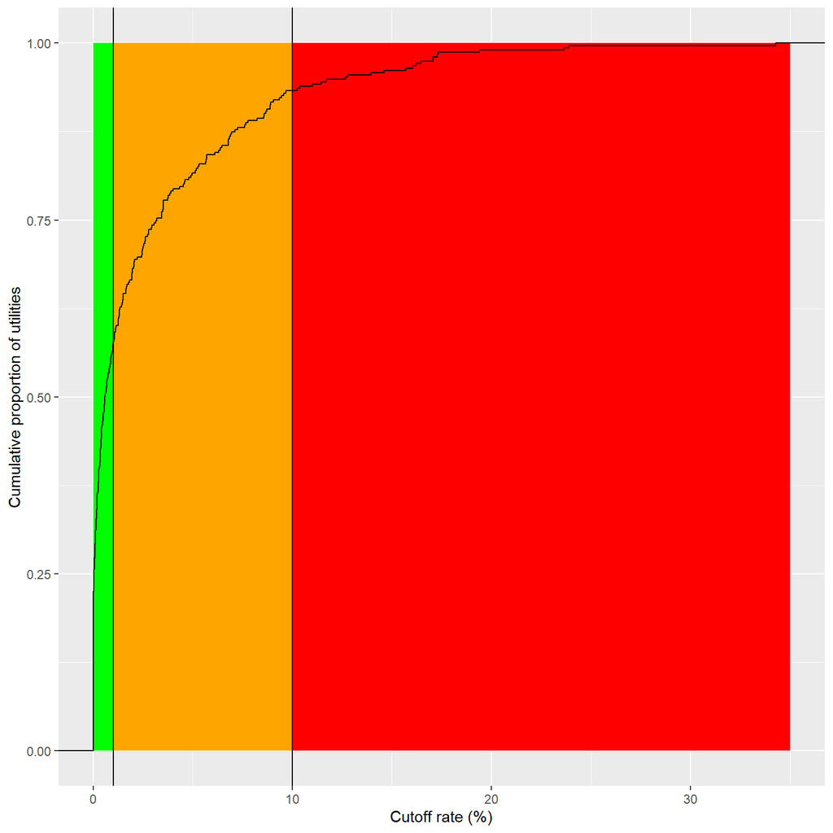

```r
#nothing
load("../data/cal-data.rds")
ggplot(D, aes(shutoffs_perc*100)) +
  geom_rect(mapping=aes(xmin=0,ymin=0,xmax=1,ymax=1), fill="green", alpha=0.5) +
  geom_rect(mapping=aes(xmin=1,ymin=0,xmax=10,ymax=1), fill="orange", alpha=0.5) +
  geom_rect(mapping=aes(xmin=10,ymin=0,xmax=35,ymax=1), fill="red", alpha=0.5) +
  stat_ecdf(geom="step") +
  geom_vline(xintercept=1) +
  geom_vline(xintercept=10) +
  ylab("Cumulative proportion of utilities") +
  xlab("Cutoff rate (%)")
```

Recall that we simulated shutoff rates, assuming this was related to HBI and PPI, which might be a plausible story. Below, we apply our shutoff grades.

```r
P1_tract <-
  P1_tract %>%
  mutate(Grade_cutoff = case_when(
    Cutoff_Perc < 1 ~ "Good",
    Cutoff_Perc >= 1 & Cutoff_Perc < 10 ~ "Fair",
    Cutoff_Perc >= 10 ~ "Poor"
  ))

map2 <- select(P1_tract,NAME,GEOID,HBI_size_avg,PPI,aff_grade_avg, Cutoff_Perc, Grade_cutoff)
mapview::mapview(map2,zcol="Grade_cutoff",layer.name="Cutoff (%) Grade")
```

[interactive chart not shown]

#### Customer Assistance Program participation

Participation should be measured as a proportion of “eligible” households. The approach here should be to set the eligible population as the proportion of families earning less than 200% of the FPL. Based on previous [participation reports](https://media.gradebuddy.com/documents/1714107/ca3c4163-ea95-438b-ad86-3f1a5558622d.pdf) from the CA Low-Income Rate Assistance Program, as well as the [LIHEAP program](https://liheappm.acf.hhs.gov/data_warehouse/index.php?report=adHocQueries) participation among this eligible population is generally between 0% and 40%, with an interquartile range of 11-22%. We can revise this to more “round” numbers of 10% and 25%.

We simulated this CAP participation rate, making assumptions related to certain demographic groups having lower participation rates than others, although most empirical evidence in the literature suggests this not to be a significant factor over the general level of outreach and application barriers to such programs. We apply the thresholds to create the 3-level grades below.

```r
P1_tract$CAP_Perc <- 200*P1_tract$CAP_Perc/P1_tract$PPI

P1_tract <-
  P1_tract %>%
  mutate(Grade_CAP = case_when(
    CAP_Perc < 10 ~ "Poor",
    CAP_Perc >= 10 & CAP_Perc < 25 ~ "Fair",
    CAP_Perc >= 25 ~ "Good"
  ))

map3 <- select(P1_tract,NAME,GEOID,HBI_size_avg,PPI,aff_grade_avg, Cutoff_Perc, Grade_cutoff, CAP_Perc, Grade_CAP)
mapview::mapview(map3,zcol="Grade_CAP",layer.name="CAP Participation/PPI (%)")
```

[interactive chart not shown]

[^1]: kyle.onda@gmail.com